# k Impact on Endemicity Analysis

### Functions

Load functions to run model, with most recent version

```r
source(here("Vfunctions", "V_stateUpdateT2.R")) # wrapper function, tracks epidemic in population over generations
source(here("Vfunctions", "V_DS_T2.R")) # updates state of population based on current generation
source(here("Vfunctions", "S_to_I_T2.R")) # infection simulation
source(here("Vfunctions", "effcIdGenT2.R")) # generating effective contact IDs
source(here("Vfunctions", "effcChecker.R")) # verifying effective contact IDs
source(here("Vfunctions", "reseedingT2.R")) # reseeding infection
```

```r
# Function to calculate median (+ IQR) Incidence at equilibrium of simulations which become endemic

endStats <- function(mat){
  eq <- mat[, (ncol(mat)-100) :ncol(mat)]
  id <- which(eq[,ncol(eq)] != 0) # which simulations became endemic
  if(length(id) == 0){
    M <- 0
    iqr <- 0
    lq <- 0
    uq <- 0
  }else if(length(id)>0){
    mEnd <- as.vector(eq[id,]) # simulations which become endemic, subset for last 100 generations
    M <- median(mEnd)
    iqr <- IQR(mEnd)
    lq <- quantile(mEnd)[2]
    uq <- quantile(mEnd)[4]
  }
  sumStat <- c(Med = M, iqr = iqr, lq = lq, uq = uq)
  return(sumStat)
  }
```

```r
endemicity <- function(Tmat){

  P_endemic <- sum(Tmat[,ncol(Tmat)]!=0) / nrow(Tmat)

  return(P_endemic)
}
```

### What Impact does the value of k have on Endemicity? (Rperiod = 1)

- What is the incidence at equilibrium, what is the variation around this?
- What proportion of simulations become endemic (for given k value)?

#### Parameters

- Refractory Period = 1 to simulate endemicity
- R0 = 3 to simulate epidemic growth
- Investigate k values between 0.1 and Infinity
- Reseeding is ON to prevent early die-out
- generations = 1000 to track endemicity
- Is there a difference depending on whether ehterogneiety is fixed or variable? (initially fixed)

```r
## Model Definition ##
runs <- 100
generations <- 100 # the number of generations (or timesteps) to run the model over
output <- "I_counts" # defines the output as "matrix" (full disease state and ID of units) or "counts" (number of units in S,I,R states or "I_counts" (returns only count of infected units over time)

## PARAMETERS ##

## Population Parameters ##

N <- 10000 # population size (may exxclude in favour of calculating in state_update function)
I0 <- 10
state_tracker <- c(rep("I", I0), rep("S", N - I0)) # initial disease state of units in population
population_sample <- "large" # large or small population (determines sampling strategy)

## Epidemiological Parameters ##

R_period <- Inf # the refractory period: 1 = no immunity, Inf = lifelong immunity
R0_estimate <- 3 # average number of effective contacts per unit
k_transmission <- Inf # overdispersion parameter, level of heterogeneity in effective contact potential: 0.1 = high heterogneiety, Inf = homogeneous

heterogeneity <- "fixed" # "fixed" or "variable", is unit transmission potential constant through time?
contact_list1 <- replicate(N, c(1:N), simplify = FALSE)
contact_list <- lapply(1:length(contact_list1),
                       function(x) contact_list1[[x]][-x])

## Reseeding Parameters ##
reseed <- FALSE # reseed 5 infections periodically during the first 10% of generations
reseed_threshold <- 0# threshold generation for reseeding events
reseed_frequency <- 0
introductions <- 0 # number of new cases introduced when reseeding occurs

## Vaccination Parameters ##
V_prop <- 0 # proportion to be vaccinated in each round
V_start <- 0 # start generation for vaccination
V_period <- 0 # duration of immunity from vaccination (by number of timesteps)
V_rounds <- 0 # number of rounds (-1 for starting round) of vaccination in programme
V_schedule <- 0 # how frequent is vacciantion (ie every 2 "years")
V_mode <- "random" #random, target or non_target, NB: target/non-target only possible if heterogneiety is fixed
```

#### Run Model:

```r
output <- "I_counts"
runs <- 100
generations <- 1000
R_period <- 1
heterogeneity <- "fixed"

k_vals <- c(0.1, 0.3, 0.5, 1, Inf)

reseed <- TRUE
reseed_threshold <- 100 # threshold generation for reseeding events
reseed_frequency <- 10
introductions <- 10

kEnd_list <- list()

system.time(
  for(k in 1:length(k_vals)){

    k_transmission <- k_vals[k]

    Runs_tracker <-
      foreach (z = 1:runs, .combine = "rbind") %dopar% {
        state_update(
          state_tracker,
          N,
          population_sample,
          generations,
          output,
          R_period,
          R0_estimate,
          k_transmission,
          heterogeneity,
          contact_list,
          reseed,
          reseed_threshold,
          reseed_frequency,
          introductions,
          V_prop,
          V_start,
          V_period,
          V_rounds,
          V_schedule,
          V_mode
        )

        #runs_ <- rbind(runs_df, Runs_tracker)

      }
    kEnd_list[[k]] <- Runs_tracker
  }
)

save(kEnd_list, file = "kEndemicity_list.RData")
```

### Impact of k on endemicity

Incidence at equilibrium + variation

- For the conditions specified ($R0 = 3; RefractoryPeriod = 1$) the value of k does not make a (noticeable) difference to the median incidence at equilibrium, there is slightly greater variation around the median (IQR) for lower values of k.

Proportion of simulations which become endemic

- For the conditions specified ($R0 = 3; RefractoryPeriod = 1$), the infection becomes endemic for all values of k between 0.1 - Inf. *These results are a reflection of the values assigned to R0 and the refractory period which support endemicity - other values for these parameters should be explored to understand how k impacts endemicity*

```
## geom_path: Each group consists of only one observation. Do you need to adjust
## the group aesthetic?
```

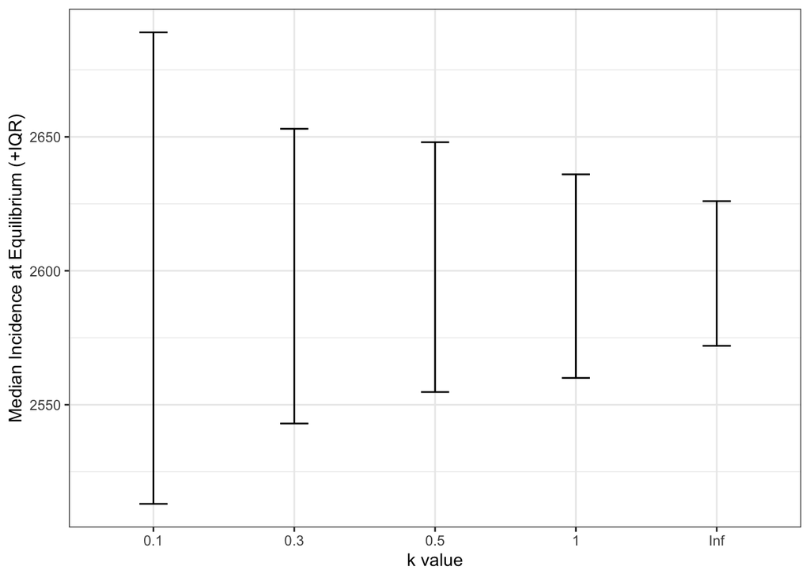

```r
# NB difference between mean epidemic when heterogeneity is fixed or variable is qualitative

load(here("data_080121/WU1/kEndemicity_list.RData"))
k_vals <- c(0.1, 0.3, 0.5, 1, Inf)

# Median Incidence at equilibrium + variance

EndStats <- t(sapply(kEnd_list, endStats)) # calculates median and quartiles for Incidence at Equilbrium over different k values
colnames(EndStats) <- c("Med", "IQR", "q1", "q3")

kEndemicIncidence <-  as.data.frame(cbind(k_vals, EndStats))


ggplot(data = kEndemicIncidence, aes(x = factor(k_vals), y = Med))+
  geom_line()+
  geom_errorbar(aes(ymin=q1, ymax=q3), width=.2)+
  xlab("k value")+
  ylab("Median Incidence at Equilibrium (+IQR)")+
  theme_bw()
```

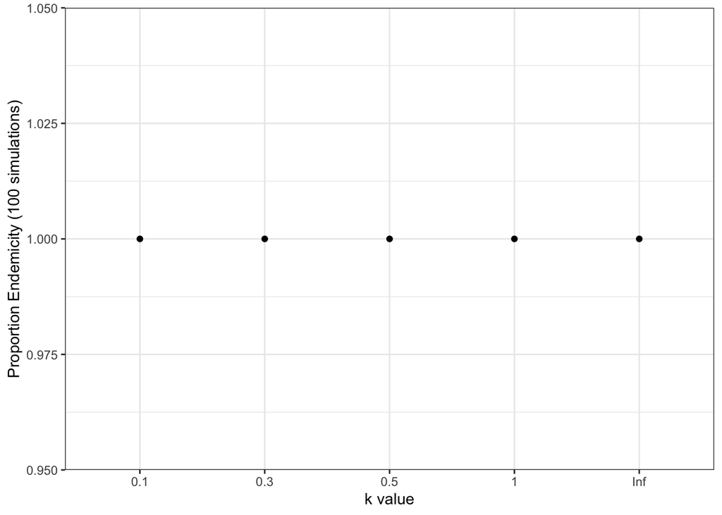

```r
# Proportion of simulations which become endemic

  pEndemicity <- sapply(kEnd_list, endemicity)

  kEndemicProp <- as.data.frame(cbind(k_vals,pEndemicity))


ggplot(data = kEndemicProp, aes(x = factor(k_vals), y = pEndemicity))+
  geom_point()+
  xlab("k value")+
  ylab("Proportion Endemicity (100 simulations)")+
  theme_bw()
```